# Data representation with R II

Univariate and bivariate graphics

O Rodriguez de Rivera Ortega, PhD

University of Exeter

```r
library(tidyverse)
library(palmerpenguins)
library(scales)

theme_set(theme_minimal(base_size = 12))

penguins_clean <- penguins %>%
  drop_na(species, island, bill_length_mm, bill_depth_mm,
          flipper_length_mm, body_mass_g, sex)
```

# 1 Univariate graphs: categorical variables

## 1.1 Bar charts: counts

Use a bar chart when the variable is categorical and the y-axis is a **count**.

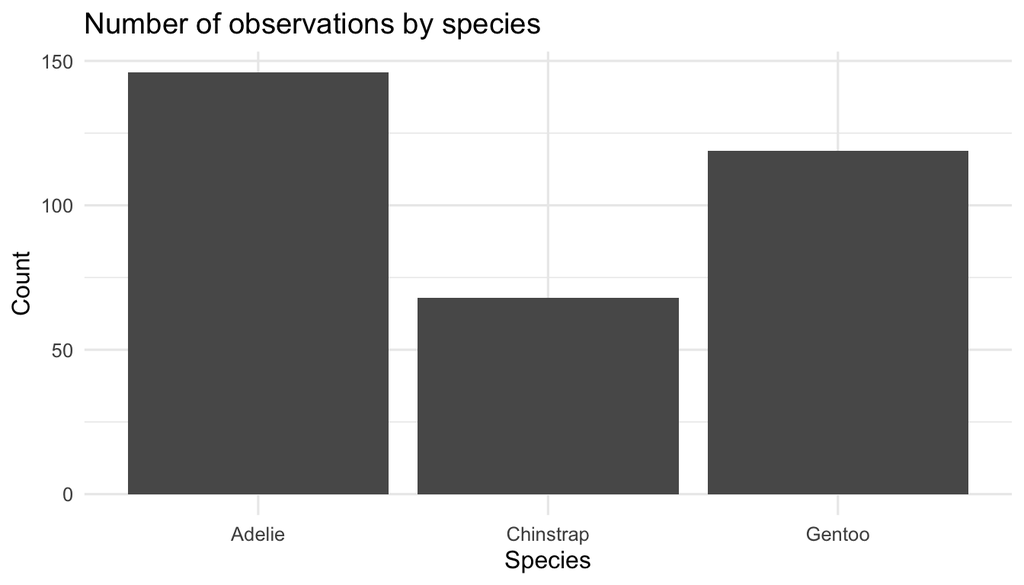

```r
ggplot(penguins_clean, aes(x = species)) +
  geom_bar() +
  labs(
    title = "Number of observations by species",
    x = "Species",
    y = "Count"
  )
```

## 1.2 Order categories

Ordering makes comparisons easier.

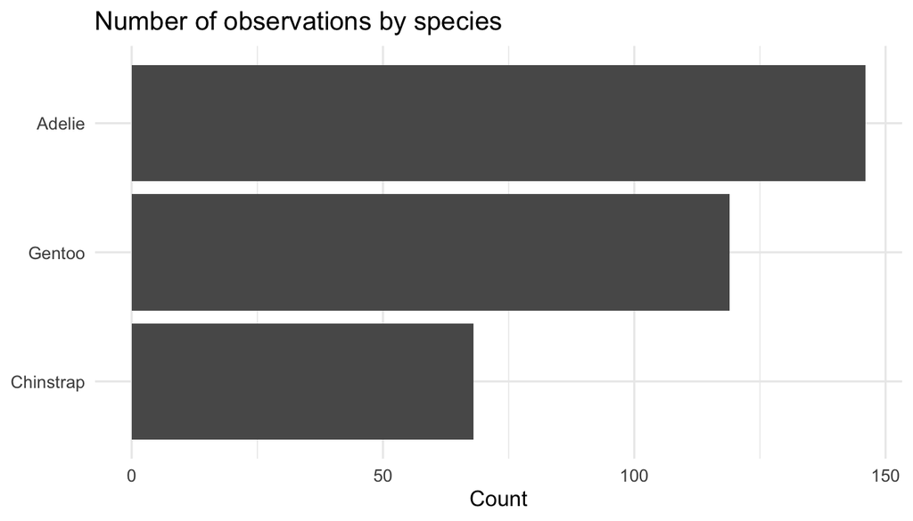

```r
penguin_counts <- penguins_clean %>%
  count(species, sort = TRUE)

ggplot(penguin_counts, aes(x = fct_reorder(species, n), y = n)) +
  geom_col() +
  coord_flip() +
  labs(
    title = "Number of observations by species",
    x = NULL,
    y = "Count"
  )
```

## 1.3 Percentages

Use proportions when the total sample size is not the main message.

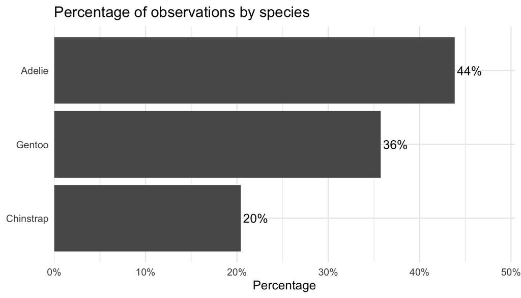

```r
penguin_counts <- penguins_clean %>%
  count(species) %>%
  mutate(prop = n / sum(n))

ggplot(penguin_counts, aes(x = fct_reorder(species, prop), y = prop)) +
  geom_col() +
  geom_text(aes(label = percent(prop, accuracy = 1)), hjust = -0.1) +
  coord_flip() +
  scale_y_continuous(labels = percent, expand = expansion(mult = c(0, 0.15))) +
  labs(
    title = "Percentage of observations by species",
    x = NULL,
    y = "Percentage"
  )
```

## 1.4 Two categorical variables

Stacked bars show composition. Position `"fill"` puts each group on a common 0–100% scale.

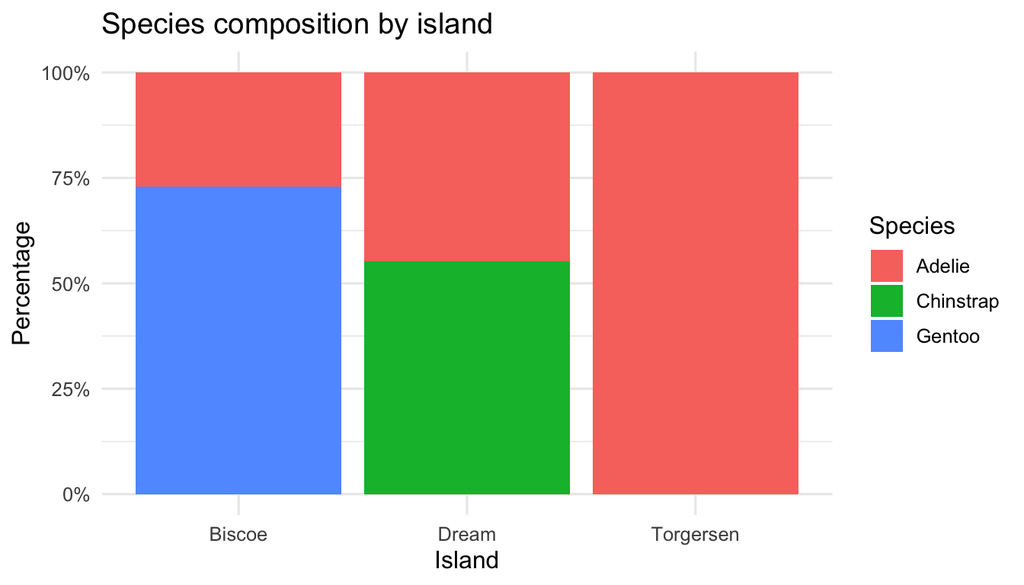

```r
ggplot(penguins_clean, aes(x = island, fill = species)) +
  geom_bar(position = "fill") +
  scale_y_continuous(labels = percent) +
  labs(
    title = "Species composition by island",
    x = "Island",
    y = "Percentage",
    fill = "Species"
  )
```

## 1.5 Grouped bars

Grouped bars are useful for direct comparison of counts.

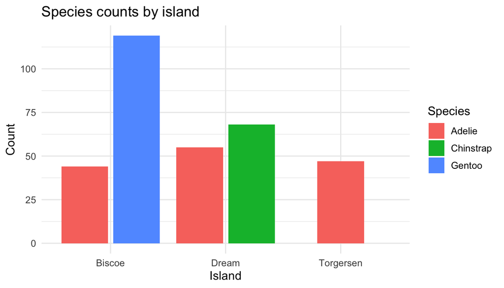

```r
ggplot(penguins_clean, aes(x = island, fill = species)) +
  geom_bar(position = position_dodge2(preserve = "single")) +
  labs(
    title = "Species counts by island",
    x = "Island",
    y = "Count",
    fill = "Species"
  )
```

# 2 Univariate graphs: quantitative variables

## 2.1 Histogram

A histogram shows the distribution of a quantitative variable. The message depends on the bin width.

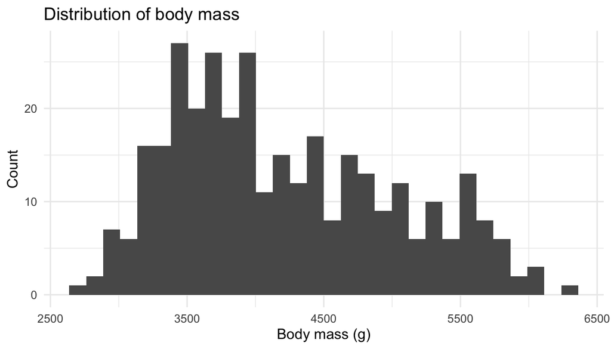

```r
ggplot(penguins_clean, aes(x = body_mass_g)) +
  geom_histogram() +
  labs(
    title = "Distribution of body mass",
    x = "Body mass (g)",
    y = "Count"
  )
```

## 2.2 Choose the bin width

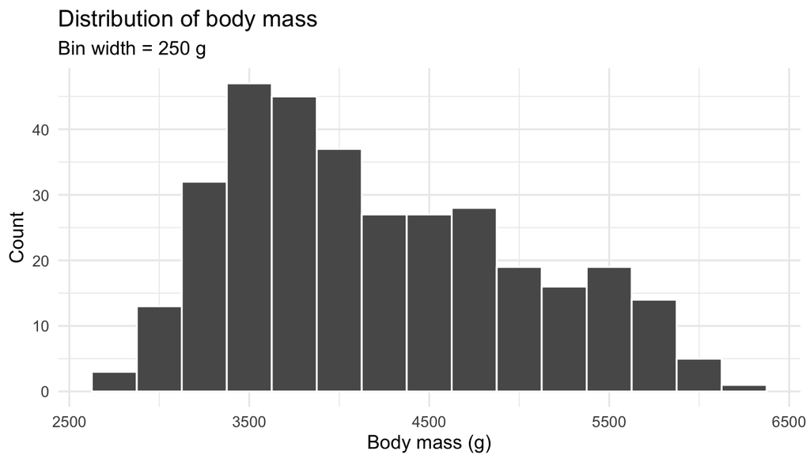

```r
ggplot(penguins_clean, aes(x = body_mass_g)) +
  geom_histogram(binwidth = 250, colour = "white") +
  labs(
    title = "Distribution of body mass",
    subtitle = "Bin width = 250 g",
    x = "Body mass (g)",
    y = "Count"
  )
```

## 2.3 Density plot

Density plots are useful for comparing smooth distributions, but they hide sample size.

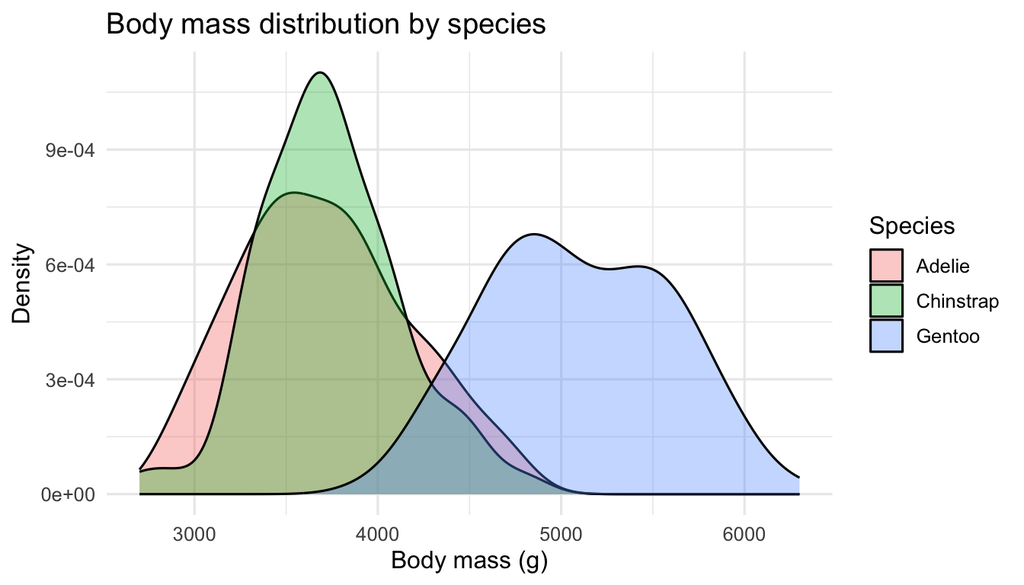

```r
ggplot(penguins_clean, aes(x = body_mass_g, fill = species)) +
  geom_density(alpha = 0.35) +
  labs(
    title = "Body mass distribution by species",
    x = "Body mass (g)",
    y = "Density",
    fill = "Species"
  )
```

## 2.4 Boxplots summarise distributions

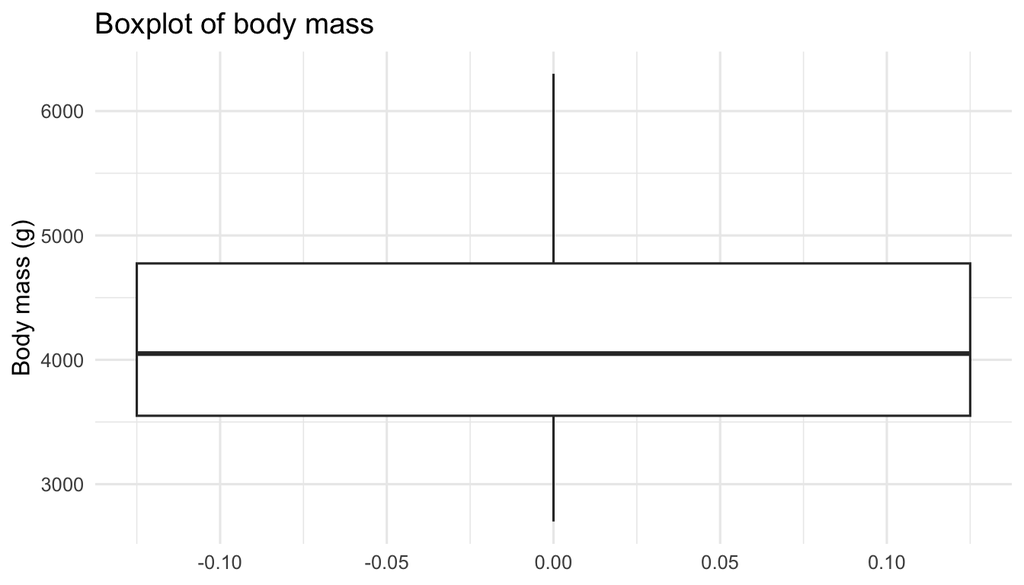

```r
ggplot(penguins_clean, aes(y = body_mass_g)) +
  geom_boxplot(width = 0.25) +
  labs(
    title = "Boxplot of body mass",
    x = NULL,
    y = "Body mass (g)"
  )
```

# 3 Bivariate graphs

## 3.1 Quantitative vs quantitative

A scatterplot is usually the first choice for two quantitative variables.

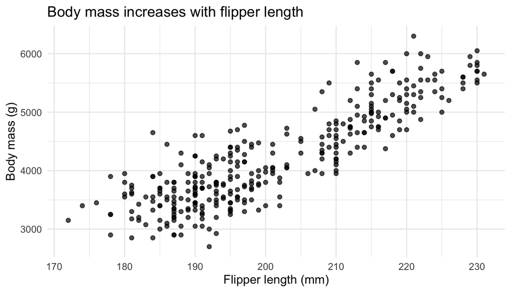

```r
ggplot(penguins_clean, aes(x = flipper_length_mm, y = body_mass_g)) +
  geom_point(alpha = 0.7) +
  labs(
    title = "Body mass increases with flipper length",
    x = "Flipper length (mm)",
    y = "Body mass (g)"
  )
```

## 3.2 Add a smooth

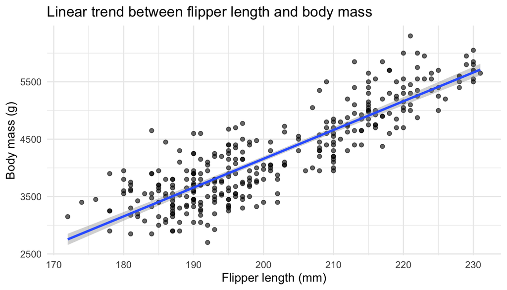

```r
ggplot(penguins_clean, aes(x = flipper_length_mm, y = body_mass_g)) +
  geom_point(alpha = 0.6) +
  geom_smooth(method = "lm") +
  labs(
    title = "Linear trend between flipper length and body mass",
    x = "Flipper length (mm)",
    y = "Body mass (g)"
  )
```

## 3.3 Show groups with colour

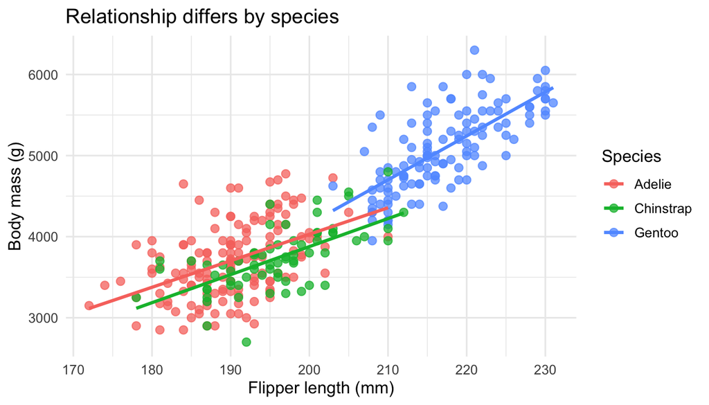

```r
ggplot(penguins_clean,
       aes(x = flipper_length_mm, y = body_mass_g, colour = species)) +
  geom_point(alpha = 0.75, size = 2.4) +
  geom_smooth(method = "lm", se = FALSE) +
  labs(
    title = "Relationship differs by species",
    x = "Flipper length (mm)",
    y = "Body mass (g)",
    colour = "Species"
  )
```

## 3.4 Dealing with overplotting

Use alpha, jitter, binning or faceting when points overlap.

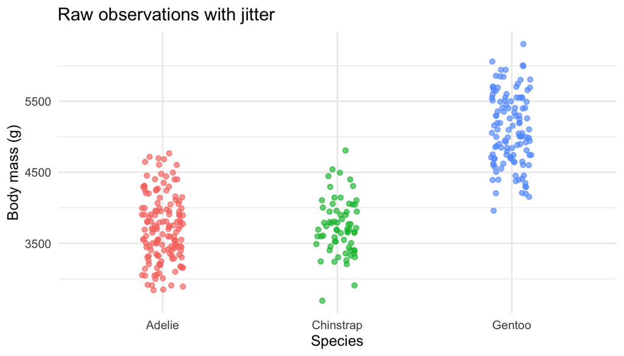

```r
ggplot(penguins_clean,
       aes(x = species, y = body_mass_g, colour = species)) +
  geom_jitter(width = 0.12, alpha = 0.65, show.legend = FALSE) +
  labs(
    title = "Raw observations with jitter",
    x = "Species",
    y = "Body mass (g)"
  )
```

# 4 Categorical vs quantitative

## 4.1 Boxplots by group

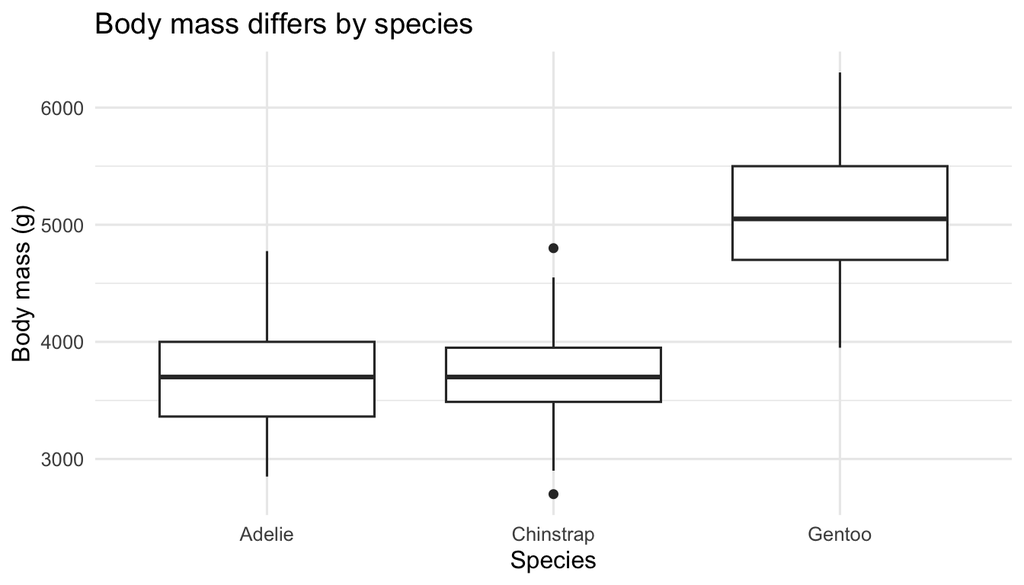

```r
ggplot(penguins_clean, aes(x = species, y = body_mass_g)) +
  geom_boxplot() +
  labs(
    title = "Body mass differs by species",
    x = "Species",
    y = "Body mass (g)"
  )
```

## 4.2 Violin + boxplot + raw points

This combines distribution shape, summary statistics and individual observations.

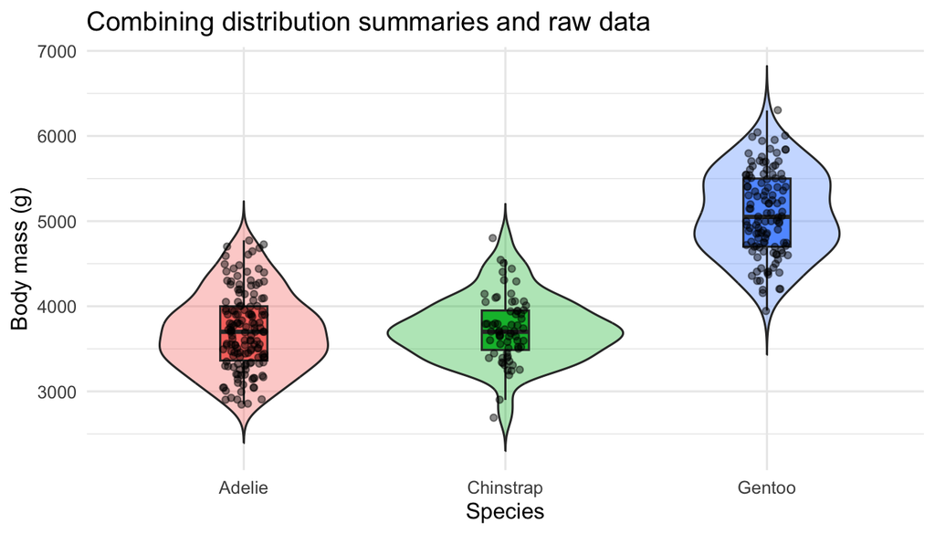

```r
ggplot(penguins_clean, aes(x = species, y = body_mass_g, fill = species)) +
  geom_violin(alpha = 0.35, trim = FALSE, show.legend = FALSE) +
  geom_boxplot(width = 0.18, outlier.shape = NA, show.legend = FALSE) +
  geom_jitter(width = 0.08, alpha = 0.45, size = 1.4, show.legend = FALSE) +
  labs(
    title = "Combining distribution summaries and raw data",
    x = "Species",
    y = "Body mass (g)"
  )
```

## 4.3 Dot chart for summaries

For summaries, points are often clearer than bars.

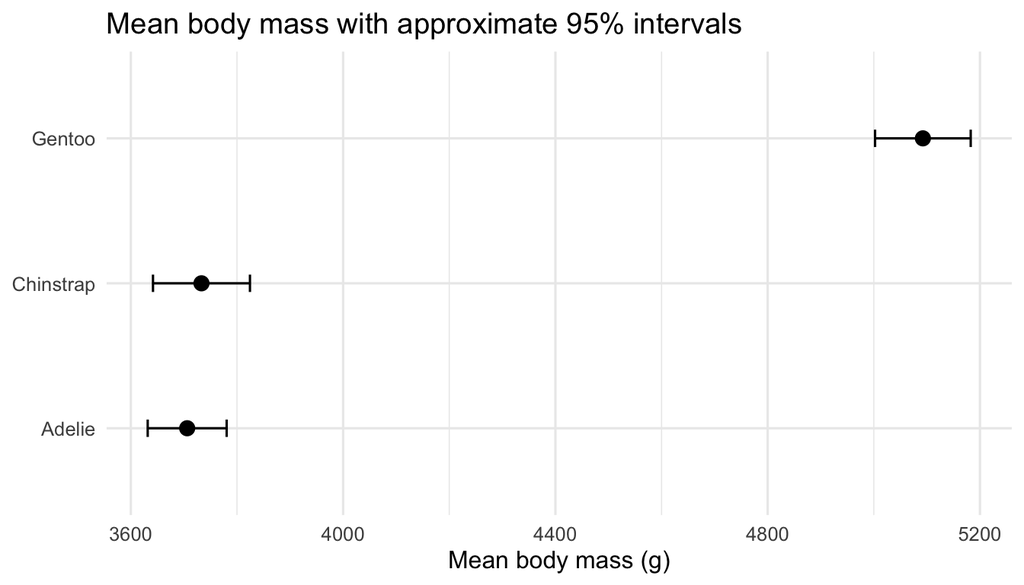

```r
species_summary <- penguins_clean %>%
  group_by(species) %>%
  summarise(
    mean_mass = mean(body_mass_g),
    se_mass = sd(body_mass_g) / sqrt(n()),
    .groups = "drop"
  )

ggplot(species_summary,
       aes(x = mean_mass, y = fct_reorder(species, mean_mass))) +
  geom_point(size = 3) +
  geom_errorbar(aes(xmin = mean_mass - 1.96 * se_mass,
                    xmax = mean_mass + 1.96 * se_mass),
                width = 0.12) +
  labs(
    title = "Mean body mass with approximate 95% intervals",
    x = "Mean body mass (g)",
    y = NULL
  )
```

# 5 Time series

## 5.1 Line plots

Use lines when the x-axis has a meaningful order, often time.

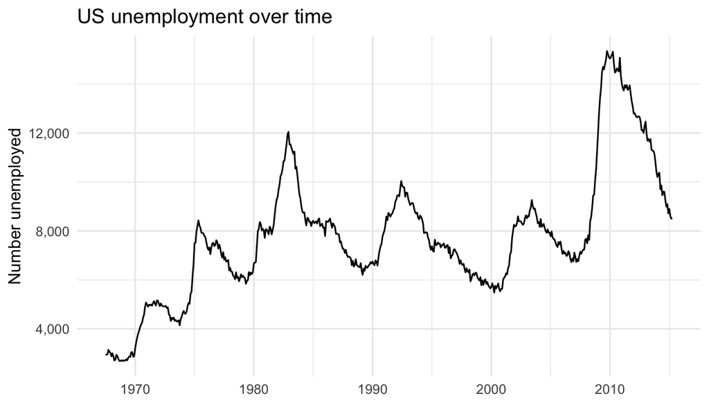

```r
ggplot(economics, aes(x = date, y = unemploy)) +
  geom_line() +
  scale_y_continuous(labels = comma) +
  labs(
    title = "US unemployment over time",
    x = NULL,
    y = "Number unemployed"
  )
```

## 5.2 Multiple lines

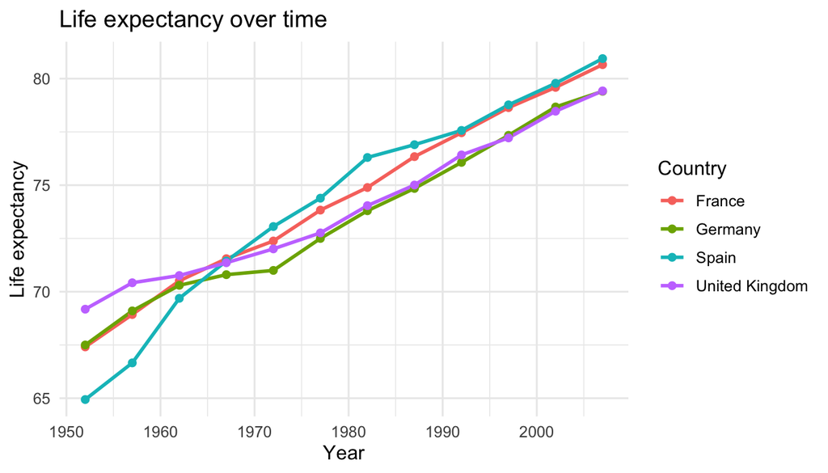

```r
library(gapminder)

gapminder %>%
  filter(country %in% c("United Kingdom", "Spain", "France", "Germany")) %>%
  ggplot(aes(x = year, y = lifeExp, colour = country)) +
  geom_line(linewidth = 1) +
  geom_point(size = 1.8) +
  labs(
    title = "Life expectancy over time",
    x = "Year",
    y = "Life expectancy",
    colour = "Country"
  )
```

# 6 Exercises

## 6.1 Exercise 2: choose the graph

Using `penguins_clean`, make one graph for each question:

1. How many observations are there for each island?
2. How does bill depth vary across species?
3. What is the relationship between bill length and bill depth?
4. Does the relationship in question 3 differ by species?

## 6.2 Exercise 3: improve a graph

The following plot works technically, but it is not very readable. Improve it.

```r
ggplot(penguins_clean, aes(x = species, y = body_mass_g, fill = sex)) +
  geom_bar(stat = "summary", fun = "mean", position = "dodge")
```

Suggestions:

- use points and uncertainty intervals instead of bars;
- add units;
- use an informative title;
- consider faceting or jittered raw data.